# PPMI-PEG mQTL / metQTL Overlap Analysis

Longitudinal mQTL meta-hits overlapped with PEG1 metabolomics QTLs, annotated via Ensembl

July 26, 2026

## Overview

This report combines four analysis stages:

1. **metQTL FDR handling and overlap** — combining PEG1 c18 + hilic trans-metQTL results, and overlapping FDR-significant SNP-metabolite pairs against the classified longitudinal PPMI mQTL results (from the meta-analysis hit list, re-tested with a mixed model across follow-up visits).
2. **Gene annotation** — resolving the overlapping SNPs to nearest/overlapping genes via the Ensembl REST API, since a shared SNP driving both a methylation and a metabolite association is the strongest signal of a pleiotropic locus worth following up.
3. **PD GWAS overlap and union table** — checking whether the case meta-analysis mQTL hits fall near a known PD risk locus from Nalls et al. (2019, Table S2), then building a union table of case hits supported by *either* the metQTL overlap *or* GWAS proximity (or both).
4. **Metabolite compound annotation** — resolving as many of the overlap metabolite features as possible from their raw `mz_rt` labels to putative compound identities, via xmsannotator mass/retention-time matching against HMDB, KEGG, and LipidMaps (see Step 6).

Metabolite features (`C18_mz_rt_...` / `HILIC_mz_rt_...`) are carried under their original mass-spec feature labels through Steps 1-5. No collaborator compound-ID mapping table ever materialized, so Step 6 instead resolves them independently via xmsannotator mass/retention-time matching — with partial coverage (23/33 features get any match, 11/33 a high-confidence named compound; see Step 6 for caveats).

**A methodological note carried through this analysis:** the `trans_metqtls.txt` files were generated with a liberal `pvOutputThreshold` (1e-2) and then manually truncated to the first 10M p-value-sorted rows to avoid an out-of-memory error on load. This means the file is *not* the full test space — a BH correction recomputed on this file alone would be invalid, since it would rank an already-preselected low-p subset against itself rather than against the true, much larger, denominator of all tests performed. We confirmed the truncation only cut into the non-significant tail (FDR ~0.75-0.85 at the last retained row of every file) and therefore use **MatrixEQTL’s own per-file FDR column** rather than recomputing it — treating c18 and hilic as separate multiple-testing families rather than one merged correction, since a combined correction isn’t recoverable from truncated data anyway.

## Step 1: Combine metQTL results and apply FDR filtering

```r
combine_and_fdr <- function(group_label, files, fdr_threshold = 0.05) {

  combined <- bind_rows(lapply(files, function(f) {
    read_tsv(f, col_types = cols(SNP = col_character(), gene = col_character(),
                                  beta = col_double(), `t-stat` = col_double(),
                                  `p-value` = col_double(), FDR = col_double()),
              guess_max = Inf) %>%
      mutate(source_file = basename(dirname(f)))
  }))

  sig <- combined %>% filter(FDR < fdr_threshold)

  out_all <- sprintf("peg1_%s_metqtl_combined_fdr.csv", group_label)
  out_sig <- sprintf("peg1_%s_metqtl_sig_fdr05.csv", group_label)
  write_csv(combined, out_all)
  write_csv(sig, out_sig)

  list(combined = combined, sig = sig)
}

cases_metqtl    <- combine_and_fdr(
  "cases",
  c("../PEG_METAB/results/metqtl/c18_peg1_cases/trans_metqtls.txt",
    "../PEG_METAB/results/metqtl/hilic_peg1_cases/trans_metqtls.txt")
)

controls_metqtl <- combine_and_fdr(
  "controls",
  c("../PEG_METAB/results/metqtl/c18_peg1_controls/trans_metqtls.txt",
    "../PEG_METAB/results/metqtl/hilic_peg1_controls/trans_metqtls.txt")
)

metqtl_cases_sig    <- cases_metqtl$sig
metqtl_controls_sig <- controls_metqtl$sig
```

```r
metqtl_summary <- tibble(
  group           = c("Cases", "Controls"),
  total_tests     = c(nrow(cases_metqtl$combined), nrow(controls_metqtl$combined)),
  fdr_sig_pairs   = c(nrow(metqtl_cases_sig), nrow(metqtl_controls_sig))
)
kable(metqtl_summary, caption = "PEG1 metQTL: total tests combined (c18+hilic) and FDR<0.05 pairs")
```

PEG1 metQTL: total tests combined (c18+hilic) and FDR<0.05 pairs

| group | total_tests | fdr_sig_pairs |
| --- | --- | --- |
| Cases | 2e+07 | 15973 |
| Controls | 2e+07 | 18627 |

## Step 2: Overlap with classified longitudinal mQTL results

Overlap is defined by shared SNP identity, cases-vs-cases and controls-vs-controls kept separate (different populations, not directly comparable). A single pleiotropic SNP can legitimately show up with multiple significant CpGs *and* multiple significant metabolites — that many-to-many structure is expected biology, not a join error.

```r
overlap_group <- function(group_label, mqtl_classified_file, metqtl_sig) {

  mqtl <- read_csv(mqtl_classified_file,
                    col_types = cols(pair_id = col_character(), snp_id = col_character(),
                                      cpg_id = col_character(), status = col_character(),
                                      warnings = col_character(), category = col_character(),
                                      same_sign_as_meta = col_logical(), replicated = col_logical(),
                                      dynamic = col_logical(), .default = col_double()),
                    guess_max = Inf)

  overlap <- mqtl %>%
    inner_join(metqtl_sig, by = c("snp_id" = "SNP"), relationship = "many-to-many") %>%
    rename(metabolite_feature = gene, metqtl_beta = beta, metqtl_pval = `p-value`, metqtl_fdr = FDR)

  write_csv(overlap, sprintf("mqtl_metqtl_overlap_%s.csv", group_label))
  overlap
}

overlap_cases <- overlap_group("cases",
  "../PPMI_LONG/longitudinal_mqtl_cases_classified.csv", metqtl_cases_sig)

overlap_controls <- overlap_group("controls",
  "../PPMI_LONG/longitudinal_mqtl_controls_classified.csv", metqtl_controls_sig)
```

```r
overlap_summary <- tibble(
  group                = c("Cases", "Controls"),
  mqtl_pairs_tested     = c(18986, 15282),
  metqtl_sig_pairs       = c(nrow(metqtl_cases_sig), nrow(metqtl_controls_sig)),
  unique_shared_snps     = c(n_distinct(overlap_cases$snp_id), n_distinct(overlap_controls$snp_id)),
  overlap_rows           = c(nrow(overlap_cases), nrow(overlap_controls))
)
kable(overlap_summary, caption = "mQTL x metQTL overlap summary")
```

mQTL x metQTL overlap summary

| group | mqtl_pairs_tested | metqtl_sig_pairs | unique_shared_snps | overlap_rows |
| --- | --- | --- | --- | --- |
| Cases | 18986 | 15973 | 59 | 104 |
| Controls | 15282 | 18627 | 116 | 128 |

### Longitudinal category breakdown among overlapping SNPs

```r
cat_cases <- overlap_cases %>% distinct(snp_id, category) %>% count(category) %>% mutate(group = "Cases")
cat_controls <- overlap_controls %>% distinct(snp_id, category) %>% count(category) %>% mutate(group = "Controls")
bind_rows(cat_cases, cat_controls) %>%
  pivot_wider(names_from = group, values_from = n, values_fill = 0) %>%
  kable(caption = "Longitudinal classification of SNPs shared with metQTL hits")
```

Longitudinal classification of SNPs shared with metQTL hits

| category | Cases | Controls |
| --- | --- | --- |
| replicated_static | 59 | 114 |
| not_replicated | 0 | 2 |

### Dynamic mQTLs (cases): metQTL overlap status

The overlap above is an *inner join* — it only shows hits that overlapped a metQTL, so a longitudinally “dynamic” mQTL with no metabolite signal would be invisible by construction. To see all dynamic hits regardless of metQTL status, we take the classified longitudinal results (cases) as the **left** table and left-join the metQTL significant set, keeping every dynamic hit whether or not it matched.

```r
cases_classified_full <- read_csv("../PPMI_LONG/longitudinal_mqtl_cases_classified.csv",
                                   col_types = cols(pair_id = col_character(), snp_id = col_character(),
                                                     cpg_id = col_character(), status = col_character(),
                                                     warnings = col_character(), category = col_character(),
                                                     same_sign_as_meta = col_logical(), replicated = col_logical(),
                                                     dynamic = col_logical(), .default = col_double()),
                                   guess_max = Inf)

dynamic_hits <- cases_classified_full %>%
  filter(category == "replicated_and_dynamic") %>%
  left_join(metqtl_cases_sig %>% select(SNP, gene, `p-value`, FDR),
            by = c("snp_id" = "SNP"), relationship = "many-to-many") %>%
  rename(metabolite_feature = gene, metqtl_pval = `p-value`, metqtl_fdr = FDR) %>%
  mutate(has_metqtl_match = !is.na(metabolite_feature))

kable(dynamic_hits %>%
        select(snp_id, cpg_id, main_beta, main_fdr, interaction_p, interaction_fdr,
               has_metqtl_match, metabolite_feature, metqtl_fdr),
      caption = "All 'replicated_and_dynamic' case mQTLs, with metQTL match status (left join — unmatched rows show NA)")
```

All ‘replicated_and_dynamic’ case mQTLs, with metQTL match status (left join — unmatched rows show NA)

| snp_id | cpg_id | main_beta | main_fdr | interaction_p | interaction_fdr | has_metqtl_match | metabolite_feature | metqtl_fdr |
| --- | --- | --- | --- | --- | --- | --- | --- | --- |
| 19:49116760 | cg14103343 | 0.0097342 | 0.0120676 | 4.6e-06 | 0.0433666 | FALSE | NA | NA |
| 19:49116359 | cg14103343 | 0.0097604 | 0.0119413 | 4.4e-06 | 0.0433666 | FALSE | NA | NA |

```r
no_metqtl <- dynamic_hits %>% filter(!has_metqtl_match)
cat("Dynamic mQTLs (cases) with NO metQTL overlap:", n_distinct(no_metqtl$snp_id), "\n")
```

```
## Dynamic mQTLs (cases) with NO metQTL overlap: 2
```

```r
kable(no_metqtl %>% select(snp_id, cpg_id, main_beta, main_fdr, interaction_p, interaction_fdr),
      caption = "Dynamic mQTLs (cases) with no corresponding metabolite QTL signal")
```

Dynamic mQTLs (cases) with no corresponding metabolite QTL signal

| snp_id | cpg_id | main_beta | main_fdr | interaction_p | interaction_fdr |
| --- | --- | --- | --- | --- | --- |
| 19:49116760 | cg14103343 | 0.0097342 | 0.0120676 | 4.6e-06 | 0.0433666 |
| 19:49116359 | cg14103343 | 0.0097604 | 0.0119413 | 4.4e-06 | 0.0433666 |

## Step 3: Gene annotation via Ensembl REST API

```r
unique_snps <- union(overlap_cases$snp_id, overlap_controls$snp_id)

WINDOW <- 250000
BASE_URL <- "https://rest.ensembl.org"

annotate_snp <- function(snp_id) {
  parts <- strsplit(snp_id, ":")[[1]]
  chr <- parts[1]
  pos <- as.integer(parts[2])

  query_region <- function(start, end) {
    url <- sprintf("%s/overlap/region/human/%s:%d-%d?feature=gene;content-type=application/json",
                    BASE_URL, chr, start, end)
    resp <- tryCatch(GET(url), error = function(e) NULL)
    if (is.null(resp) || status_code(resp) != 200) return(NULL)
    fromJSON(content(resp, as = "text", encoding = "UTF-8"), flatten = TRUE)
  }

  hit <- query_region(pos, pos)
  Sys.sleep(0.1)

  if (!is.null(hit) && length(hit) > 0 && is.data.frame(hit) && nrow(hit) > 0) {
    gene_labels <- ifelse(is.na(hit$external_name) | hit$external_name == "",
                           hit$id, hit$external_name)
    genes <- unique(gene_labels)
    return(tibble(snp_id = snp_id, gene = paste(genes, collapse = ";"),
                   relationship = "overlapping", distance_bp = 0))
  }

  hit_wide <- query_region(max(1, pos - WINDOW), pos + WINDOW)
  Sys.sleep(0.1)

  if (is.null(hit_wide) || length(hit_wide) == 0 || !is.data.frame(hit_wide) || nrow(hit_wide) == 0) {
    return(tibble(snp_id = snp_id, gene = NA_character_,
                   relationship = paste0("none_within_", WINDOW, "bp"), distance_bp = NA_integer_))
  }

  hit_wide <- hit_wide %>%
    mutate(dist = pmax(0, pmax(start - pos, pos - end)),
           gene_label = ifelse(is.na(external_name) | external_name == "", id, external_name))

  nearest <- hit_wide %>% slice_min(dist, n = 1, with_ties = FALSE)

  tibble(snp_id = snp_id, gene = nearest$gene_label,
         relationship = "nearest", distance_bp = nearest$dist)
}

annotations <- map_dfr(unique_snps, function(s) {
  tryCatch(annotate_snp(s), error = function(e) {
    tibble(snp_id = s, gene = NA_character_, relationship = "query_failed", distance_bp = NA_integer_)
  })
})

write_csv(annotations, "overlap_snp_gene_annotations.csv")

overlap_cases_annot <- overlap_cases %>%
  left_join(annotations, by = "snp_id") %>%
  rename(nearest_gene = gene, gene_relationship = relationship, gene_distance_bp = distance_bp)

overlap_controls_annot <- overlap_controls %>%
  left_join(annotations, by = "snp_id") %>%
  rename(nearest_gene = gene, gene_relationship = relationship, gene_distance_bp = distance_bp)

write_csv(overlap_cases_annot, "mqtl_metqtl_overlap_cases_annotated.csv")
write_csv(overlap_controls_annot, "mqtl_metqtl_overlap_controls_annotated.csv")
```

### Annotation outcome

```r
kable(as.data.frame(table(relationship = annotations$relationship)),
      caption = "SNP -> gene annotation outcome (overlapping gene body, nearest within 250kb, or none found)")
```

SNP -> gene annotation outcome (overlapping gene body, nearest within 250kb, or none found)

| relationship | Freq |
| --- | --- |
| nearest | 42 |
| overlapping | 133 |

### Genes implicated, cases

```r
genes_cases <- overlap_cases_annot %>%
  distinct(snp_id, nearest_gene) %>%
  filter(!is.na(nearest_gene), nearest_gene != "") %>%
  count(nearest_gene, sort = TRUE)

kable(genes_cases, caption = "Unique genes implicated by shared SNPs — Cases")
```

Unique genes implicated by shared SNPs — Cases

| nearest_gene | n |
| --- | --- |
| ERLIN1 | 18 |
| LINC00354 | 13 |
| RUNX1 | 10 |
| ENSG00000303985 | 3 |
| MYT1L | 2 |
| PARP10 | 2 |
| SPCS2P2 | 2 |
| CYP2C23P | 1 |
| ENSG00000266667 | 1 |
| ENSG00000289410 | 1 |
| MGAT5B | 1 |
| SPATC1;PARP10 | 1 |

### Genes implicated, controls

```r
genes_controls <- overlap_controls_annot %>%
  distinct(snp_id, nearest_gene) %>%
  filter(!is.na(nearest_gene), nearest_gene != "") %>%
  count(nearest_gene, sort = TRUE)

kable(genes_controls, caption = "Unique genes implicated by shared SNPs — Controls")
```

Unique genes implicated by shared SNPs — Controls

| nearest_gene | n |
| --- | --- |
| SCAND3 | 15 |
| GPX6 | 14 |
| RADIL | 9 |
| GPX5 | 8 |
| NOL9 | 6 |
| ENSG00000286819 | 4 |
| PGBD1 | 4 |
| LINC00511 | 3 |
| ZDHHC1 | 3 |
| ZSCAN31 | 3 |
| ENSG00000300715;ZSCAN12 | 2 |
| ZSCAN9 | 2 |
| BOLA2B | 1 |
| COX11P1 | 1 |
| ENSG00000256824;ENSG00000256481;FLRT1;MACROD1 | 1 |
| ENSG00000273712;ENSG00000294464;ZSCAN31 | 1 |
| ENSG00000276302;ZSCAN26 | 1 |
| ENSG00000290870;POLR1HASP | 1 |
| ENSG00000294464;ZSCAN31 | 1 |
| ENSG00000299506;ZDHHC1 | 1 |
| ENSG00000300257 | 1 |
| ENSG00000310015;ZSCAN23 | 1 |
| KCNH2 | 1 |
| LINC01090 | 1 |
| LINC02832 | 1 |
| PTPRN2 | 1 |
| STAT5A | 1 |
| TPPP3 | 1 |
| ZBED9-AS1;SCAND3 | 1 |
| ZKSCAN4 | 1 |
| ZSCAN12 | 1 |
| ZSCAN23 | 1 |
| ZSCAN31;ZKSCAN3 | 1 |

### Gene frequency, top hits

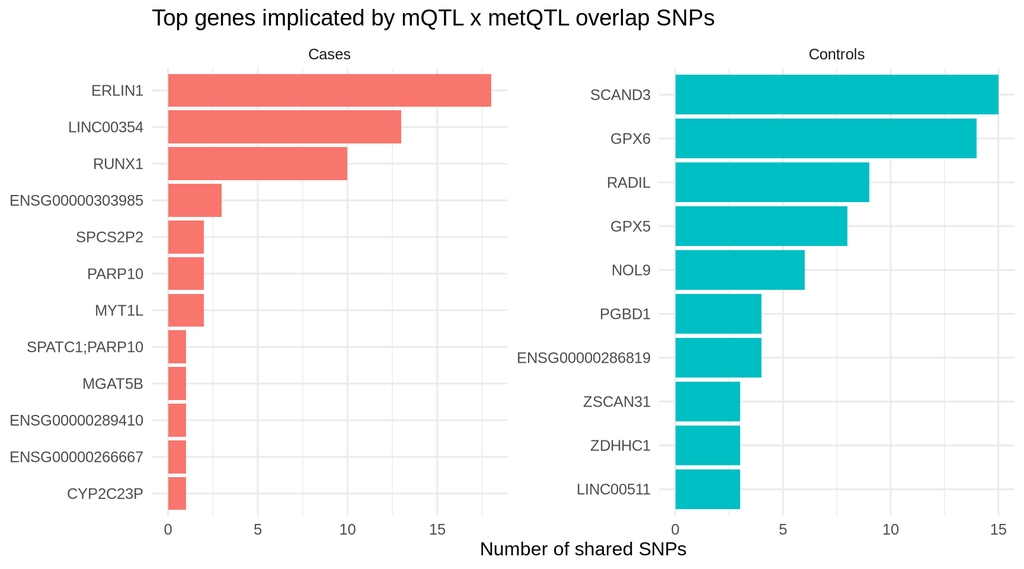

```r
top_genes <- bind_rows(
  genes_cases %>% mutate(group = "Cases"),
  genes_controls %>% mutate(group = "Controls")
) %>%
  group_by(group) %>%
  slice_max(n, n = 10) %>%
  ungroup()

ggplot(top_genes, aes(x = reorder(nearest_gene, n), y = n, fill = group)) +
  geom_col(show.legend = FALSE) +
  coord_flip() +
  facet_wrap(~group, scales = "free") +
  labs(x = NULL, y = "Number of shared SNPs",
       title = "Top genes implicated by mQTL x metQTL overlap SNPs") +
  theme_minimal(base_size = 12)
```

## Step 4: Overlap with Nalls et al. PD GWAS loci

Using the curated Nalls et al. (2019) locus table (Table S2) — already restricted to genome-wide significant, LD-independent lead SNPs — rather than the looser nominal-significance (p<0.05) SNP list, since the latter would flag a large fraction of any SNP set as a “GWAS hit” by chance alone.

Because these are independent lead SNPs from a clumping procedure, they are unlikely to be the exact variant present in the PPMI/PEG genotype panel. We therefore use a **window-based match (±250kb)** rather than requiring identical `chr:pos` — the same logic used for the Ensembl gene-annotation step above. This window is a judgment call; tighten or loosen `GWAS_WINDOW` below as appropriate.

```r
GWAS_WINDOW <- 250000   # bp; matches the Ensembl gene-annotation window

nalls_raw <- read_tsv("../external/Nalls_GWAS/PDNallsP005_TableS2.csv",
                       col_types = cols(.default = col_character()), guess_max = Inf)

qtl_gene_col   <- grep("QTL_Nominated_Gene", names(nalls_raw), value = TRUE)[1]
p_all_col      <- grep("^P_all_studies$", names(nalls_raw), value = TRUE)[1]
locus_num_col  <- grep("Locus_Number", names(nalls_raw), value = TRUE)[1]

nalls <- nalls_raw %>%
  transmute(
    nalls_snp     = SNP,
    CHR           = as.integer(CHR),
    BP            = as.integer(gsub(",", "", BP)),
    nearest_gene  = Nearest_Gene,
    qtl_gene      = .data[[qtl_gene_col]],
    p_all_studies = as.numeric(.data[[p_all_col]]),
    locus_number  = as.integer(.data[[locus_num_col]])
  )

stopifnot("Nalls BP parsing failed" = sum(is.na(nalls$BP)) == 0)
stopifnot("Nalls CHR parsing failed" = sum(is.na(nalls$CHR)) == 0)

cat("Nalls loci loaded:", nrow(nalls), "\n")
```

```
## Nalls loci loaded: 90
```

```r
cases_meta <- read_csv("../PPMI_LONG/longitudinal_mqtl_cases_classified.csv",
                        col_types = cols(pair_id = col_character(), snp_id = col_character(),
                                          cpg_id = col_character(), status = col_character(),
                                          warnings = col_character(), category = col_character(),
                                          same_sign_as_meta = col_logical(), replicated = col_logical(),
                                          dynamic = col_logical(), .default = col_double()),
                        guess_max = Inf)

case_snps <- cases_meta %>%
  distinct(snp_id) %>%
  mutate(chr = str_extract(snp_id, "^[^:]+"),
         pos = as.integer(str_extract(snp_id, "(?<=:)[0-9]+")))

match_gwas <- function(chr, pos) {
  cand <- nalls %>% filter(as.character(CHR) == chr)
  if (nrow(cand) == 0) {
    return(tibble(is_gwas_hit = FALSE, gwas_dist_bp = NA_integer_,
                   gwas_nearest_gene = NA_character_, gwas_locus_number = NA_integer_))
  }
  dists <- abs(cand$BP - pos)
  i <- which.min(dists)
  tibble(is_gwas_hit = dists[i] <= GWAS_WINDOW, gwas_dist_bp = dists[i],
         gwas_nearest_gene = cand$nearest_gene[i], gwas_locus_number = cand$locus_number[i])
}

gwas_matches <- case_snps %>%
  mutate(m = pmap(list(chr, pos), match_gwas)) %>%
  unnest(m)

cat("Unique case-hit SNPs tested against Nalls loci:", nrow(gwas_matches), "\n")
```

```
## Unique case-hit SNPs tested against Nalls loci: 16572
```

```r
cat("Within", GWAS_WINDOW/1000, "kb of a known PD GWAS locus:", sum(gwas_matches$is_gwas_hit), "\n")
```

```
## Within 250 kb of a known PD GWAS locus: 702
```

### GWAS-adjacent case hits

```r
gwas_hits_table <- gwas_matches %>%
  filter(is_gwas_hit) %>%
  arrange(gwas_dist_bp) %>%
  select(snp_id, gwas_nearest_gene, gwas_locus_number, gwas_dist_bp)

kable(gwas_hits_table, caption = "Case mQTL SNPs within 250kb of a known Nalls et al. PD GWAS locus")
```

Case mQTL SNPs within 250kb of a known Nalls et al. PD GWAS locus

| snp_id | gwas_nearest_gene | gwas_locus_number | gwas_dist_bp |
| --- | --- | --- | --- |
| 6:30108751 | TRIM40 | 30 | 68 |
| 4:77148213 | FAM47E | 22 | 244 |
| 2:169109956 | STK39 | 11 | 438 |
| 4:77148601 | FAM47E | 22 | 632 |
| 4:77148761 | FAM47E | 22 | 792 |
| 4:77149119 | FAM47E | 22 | 1150 |
| 2:169109230 | STK39 | 11 | 1164 |
| 4:77149540 | FAM47E | 22 | 1571 |
| 4:77149772 | FAM47E | 22 | 1803 |
| 4:77145892 | FAM47E | 22 | 2077 |
| 6:30106493 | TRIM40 | 30 | 2190 |
| 6:30106202 | TRIM40 | 30 | 2481 |
| 4:77150468 | FAM47E | 22 | 2499 |
| 13:49930369 | CAB39L | 53 | 2637 |
| 4:77150655 | FAM47E | 22 | 2686 |
| 2:169107532 | STK39 | 11 | 2862 |
| 4:77150838 | FAM47E | 22 | 2869 |
| 13:49930643 | CAB39L | 53 | 2911 |
| 4:77151109 | FAM47E | 22 | 3140 |
| 4:77151110 | FAM47E | 22 | 3141 |
| 6:32581922 | HLA-DRB5 | 31 | 3150 |
| 6:30105391 | TRIM40 | 30 | 3292 |
| 4:77151300 | FAM47E | 22 | 3331 |
| 2:169113808 | STK39 | 11 | 3414 |
| 2:169106850 | STK39 | 11 | 3544 |
| 2:169114387 | STK39 | 11 | 3993 |
| 6:30104597 | TRIM40 | 30 | 4086 |
| 2:169115051 | STK39 | 11 | 4657 |
| 6:30103923 | TRIM40 | 30 | 4760 |
| 2:169116027 | STK39 | 11 | 5633 |

[output cut: 672 more lines]

## Step 5: Union table — cases supported by metQTL, GWAS, or both

```r
metqtl_snp_set <- unique(metqtl_cases_sig$SNP)

union_table <- cases_meta %>%
  mutate(in_metqtl = snp_id %in% metqtl_snp_set) %>%
  left_join(gwas_matches %>% select(snp_id, is_gwas_hit, gwas_dist_bp,
                                     gwas_nearest_gene, gwas_locus_number),
            by = "snp_id") %>%
  rename(in_gwas = is_gwas_hit) %>%
  left_join(overlap_cases %>% distinct(snp_id, metabolite_feature),
            by = "snp_id", relationship = "many-to-many") %>%
  # Union criteria: metQTL support, GWAS proximity, OR longitudinal dynamic
  # classification — a dynamic hit is of interest in its own right even
  # without external metQTL/GWAS support, per the earlier left-join finding
  # that 2 dynamic case hits had no metQTL overlap.
  mutate(union_hit = in_metqtl | in_gwas | dynamic) %>%
  filter(union_hit)

write_csv(union_table, "cases_union_metqtl_or_gwas.csv")

cat("Total case pairs in union (metQTL, GWAS, and/or dynamic):", nrow(union_table), "\n")
```

```
## Total case pairs in union (metQTL, GWAS, and/or dynamic): 927
```

```r
cat("Unique SNPs in union:", n_distinct(union_table$snp_id), "\n")
```

```
## Unique SNPs in union: 763
```

```r
cat("  - metQTL only:            ", n_distinct(union_table$snp_id[union_table$in_metqtl & !union_table$in_gwas & !union_table$dynamic]), "\n")
```

```
##   - metQTL only:             59
```

```r
cat("  - GWAS only:              ", n_distinct(union_table$snp_id[!union_table$in_metqtl & union_table$in_gwas & !union_table$dynamic]), "\n")
```

```
##   - GWAS only:               702
```

```r
cat("  - Dynamic only (neither):  ", n_distinct(union_table$snp_id[!union_table$in_metqtl & !union_table$in_gwas & union_table$dynamic]), "\n")
```

```
##   - Dynamic only (neither):   2
```

```r
cat("  - metQTL + GWAS:          ", n_distinct(union_table$snp_id[union_table$in_metqtl & union_table$in_gwas & !union_table$dynamic]), "\n")
```

```
##   - metQTL + GWAS:           0
```

```r
cat("  - Any combo incl. dynamic:", n_distinct(union_table$snp_id[union_table$dynamic & (union_table$in_metqtl | union_table$in_gwas)]), "\n")
```

```
##   - Any combo incl. dynamic: 0
```

```r
union_table %>%
  distinct(snp_id, cpg_id, category, in_metqtl, in_gwas, dynamic,
           metabolite_feature, gwas_nearest_gene, gwas_dist_bp) %>%
  arrange(desc(dynamic), desc(in_metqtl & in_gwas)) %>%
  kable(caption = "Case meta-hits supported by metQTL overlap, GWAS proximity, and/or longitudinal dynamic classification")
```

Case meta-hits supported by metQTL overlap, GWAS proximity, and/or longitudinal dynamic classification

| snp_id | cpg_id | category | in_metqtl | in_gwas | dynamic | metabolite_feature | gwas_nearest_gene | gwas_dist_bp |
| --- | --- | --- | --- | --- | --- | --- | --- | --- |
| 19:49116760 | cg14103343 | replicated_and_dynamic | FALSE | FALSE | TRUE | NA | SPPL2B | 46775713 |
| 19:49116359 | cg14103343 | replicated_and_dynamic | FALSE | FALSE | TRUE | NA | SPPL2B | 46775312 |
| 6:112149373 | cg26846943 | replicated_static | FALSE | TRUE | FALSE | NA | FYN | 93918 |
| 6:112148293 | cg26846943 | replicated_static | FALSE | TRUE | FALSE | NA | FYN | 94998 |
| 6:112147107 | cg26846943 | replicated_static | FALSE | TRUE | FALSE | NA | FYN | 96184 |
| 6:112141908 | cg26846943 | replicated_static | FALSE | TRUE | FALSE | NA | FYN | 101383 |
| 6:112141732 | cg26846943 | replicated_static | FALSE | TRUE | FALSE | NA | FYN | 101559 |
| 6:112114249 | cg26846943 | replicated_static | FALSE | TRUE | FALSE | NA | FYN | 129042 |
| 6:112114308 | cg26846943 | replicated_static | FALSE | TRUE | FALSE | NA | FYN | 128983 |
| 6:112114791 | cg26846943 | replicated_static | FALSE | TRUE | FALSE | NA | FYN | 128500 |
| 6:112113938 | cg26846943 | replicated_static | FALSE | TRUE | FALSE | NA | FYN | 129353 |
| 6:112138294 | cg26846943 | replicated_static | FALSE | TRUE | FALSE | NA | FYN | 104997 |
| 6:112131578 | cg26846943 | replicated_static | FALSE | TRUE | FALSE | NA | FYN | 111713 |
| 6:112121766 | cg26846943 | replicated_static | FALSE | TRUE | FALSE | NA | FYN | 121525 |
| 6:112119981 | cg26846943 | replicated_static | FALSE | TRUE | FALSE | NA | FYN | 123310 |
| 6:112121096 | cg26846943 | replicated_static | FALSE | TRUE | FALSE | NA | FYN | 122195 |
| 6:112128947 | cg26846943 | replicated_static | FALSE | TRUE | FALSE | NA | FYN | 114344 |
| 6:112119619 | cg26846943 | replicated_static | FALSE | TRUE | FALSE | NA | FYN | 123672 |
| 6:112130478 | cg26846943 | replicated_static | FALSE | TRUE | FALSE | NA | FYN | 112813 |
| 6:112118505 | cg26846943 | replicated_static | FALSE | TRUE | FALSE | NA | FYN | 124786 |
| 6:112115355 | cg26846943 | replicated_static | FALSE | TRUE | FALSE | NA | FYN | 127936 |
| 6:112116451 | cg26846943 | replicated_static | FALSE | TRUE | FALSE | NA | FYN | 126840 |
| 6:112125335 | cg26846943 | replicated_static | FALSE | TRUE | FALSE | NA | FYN | 117956 |
| 6:112132032 | cg26846943 | replicated_static | FALSE | TRUE | FALSE | NA | FYN | 111259 |
| 6:112124438 | cg26846943 | replicated_static | FALSE | TRUE | FALSE | NA | FYN | 118853 |
| 6:112124440 | cg26846943 | replicated_static | FALSE | TRUE | FALSE | NA | FYN | 118851 |
| 6:112121228 | cg26846943 | replicated_static | FALSE | TRUE | FALSE | NA | FYN | 122063 |
| 6:112122226 | cg26846943 | replicated_static | FALSE | TRUE | FALSE | NA | FYN | 121065 |
| 6:112110528 | cg26846943 | replicated_static | FALSE | TRUE | FALSE | NA | FYN | 132763 |
| 6:112111394 | cg26846943 | replicated_static | FALSE | TRUE | FALSE | NA | FYN | 131897 |

[output cut: 897 more lines]

## Step 6: Metabolite compound annotation (xmsannotator)

No collaborator compound-ID mapping table for the overlap metabolite features ever materialized, so this step resolves them independently: mass/retention-time matching (10ppm, ±30s) against the HMDB, KEGG, and LipidMaps reference databases via xmsannotator, run separately per platform (`c18`/`hilic`) and database in `annotate_overlap_metabolites_xmsannotator.R`. `c18`/`LipidMaps` did not finish that run (only 2 initial DB matches, stopped short of a compound call); the other 5 platform/db combinations completed. `rerun_step3_matching.R` re-derives the consolidated match tables read in below from that run’s on-disk output without re-running the (expensive) annotation itself.

```r
best_annotation <- read_csv("overlap_metabolite_best_annotation.csv", show_col_types = FALSE) %>%
  select(metabolite_feature, annotated_compound, confidence, score, source)

n_any_match  <- n_distinct(best_annotation$metabolite_feature)
named_match  <- best_annotation %>% filter(confidence == 2, !annotated_compound %in% c("", "-"))

cat("Overlap metabolite features with any mz/rt match:      ", n_any_match, "/ 33\n")
```

```
## Overlap metabolite features with any mz/rt match:       23 / 33
```

```r
cat("Overlap metabolite features with a high-confidence,\n",
    "named compound match:                                 ", nrow(named_match), "/ 33\n")
```

```
## Overlap metabolite features with a high-confidence,
##  named compound match:                                  11 / 33
```

```r
overlap_cases_compounds <- overlap_cases_annot %>%
  left_join(best_annotation, by = "metabolite_feature")

overlap_controls_compounds <- overlap_controls_annot %>%
  left_join(best_annotation, by = "metabolite_feature")

union_table <- union_table %>%
  left_join(best_annotation, by = "metabolite_feature")

write_csv(overlap_cases_compounds, "mqtl_metqtl_overlap_cases_annotated_compounds.csv")
write_csv(overlap_controls_compounds, "mqtl_metqtl_overlap_controls_annotated_compounds.csv")
write_csv(union_table, "cases_union_metqtl_or_gwas.csv")
```

### Annotated compounds

A `confidence` of 2 / `score` of 100000 marks xmsannotator’s high-confidence named calls; `confidence` 0 entries are a raw mass/RT hit only (frequently without a resolvable compound name) and are not treated as identifications below.

```r
named_match %>%
  arrange(source, metabolite_feature) %>%
  select(metabolite_feature, annotated_compound, source) %>%
  kable(caption = "High-confidence (confidence = 2) compound matches for overlap metabolite features")
```

High-confidence (confidence = 2) compound matches for overlap metabolite features

| metabolite_feature | annotated_compound | source |
| --- | --- | --- |
| C18_mz_rt_180.067_36.514 | N-Hydroxy-L-phenylalanine;2-(Hydroxyamino)-3-phenylpropanoate | c18_KEGG |
| C18_mz_rt_274.039_31.579 | L-Tyrosine methyl ester 4-sulfate | c18_KEGG |
| C18_mz_rt_276.018_28.086 | N-Phosphoguanidinoethyl methyl phosphate | c18_KEGG |
| HILIC_mz_rt_217.155_81.683 | Valyl-Valine | hilic_HMDB |
| HILIC_mz_rt_253.143_145.88 | QH(2) | hilic_HMDB |
| HILIC_mz_rt_278.037_62.69 | ()-Furilazole | hilic_HMDB |
| HILIC_mz_rt_161.128_100.935 | N6-Methyl-L-lysine | hilic_KEGG |
| HILIC_mz_rt_353.343_289.84 | 111519-trimethyl-5Z-eicosenoic acid | hilic_LipidMaps |
| HILIC_mz_rt_409.313_37.218 | 4Z7Z10Z13Z16Z19Z22Z25Z-octacosaoctaenoic acid | hilic_LipidMaps |
| HILIC_mz_rt_412.307_39.743 | N-(9Z-octadecenoyl)-glutamic acid | hilic_LipidMaps |
| HILIC_mz_rt_574.454_36.356 | N-(tetradecanoyl)-deoxysphing-4-enine-1-sulfonate | hilic_LipidMaps |